# Transformation of Response Variables

Mary Fisher

March 6, 2020

Check the distributions for each predictor variable, and use the box-cox function on a simple linear model to determine the suggested transformation.

**NOTE:** most of the non-normal response variables follow a poisson distribution, or a zero-inflated poisson distribution. instead of applying a transformation to the response *and* predictors, we could also just use a GLM with a Poisson link function.

Our model data:

```r
mydat1 <- read.csv(here::here("data","kelp_prediction_data_complete.csv")) %>%
  clean_names()
colnames(mydat1)
```

```
##  [1] "year"                   "month"                  "site"
##  [4] "mapy_mean_density"      "mapy_mean_count"        "mapy_mean_fronds"
##  [7] "mapy_max_fronds"        "mapy_mean_hld"          "mapy_max_hld"
## [10] "franciscanus_abundance" "purpuratus_abundance"   "urchin_abundance"
## [13] "max_ammonia"            "max_no2_no3"            "max_po4"
## [16] "max_poc"                "max_pon"                "max_tchl"
## [19] "mean_ammonia"           "mean_no2_no3"           "mean_po4"
## [22] "mean_poc"               "mean_pon"               "mean_tchl"
## [25] "summer_mean_temp"       "summer_var_temp"        "winter_mean_temp"
## [28] "winter_var_temp"
```

```r
mydat2 <- read.csv(here::here("data","biomass_prediction_data_waterchem_bysite_complete.csv")) %>%
  clean_names()
colnames(mydat2)
```

```
##  [1] "year"                 "month"                "site"
##  [4] "fish_total_biomass"   "fish_diversity"       "invert_total_biomass"
##  [7] "invert_diversity"     "algae_total_biomass"  "algae_diversity"
## [10] "kelp_total_biomass"   "summer_mean_temp"     "summer_var_temp"
## [13] "winter_mean_temp"     "winter_var_temp"      "max_ammonia"
## [16] "max_no2_no3"          "max_po4"              "max_poc"
## [19] "max_pon"              "max_tchl"             "mean_ammonia"
## [22] "mean_no2_no3"         "mean_po4"             "mean_poc"
## [25] "mean_pon"             "mean_tchl"
```

# Question 1: Kelp Growth & Size

## Distributions

### Response

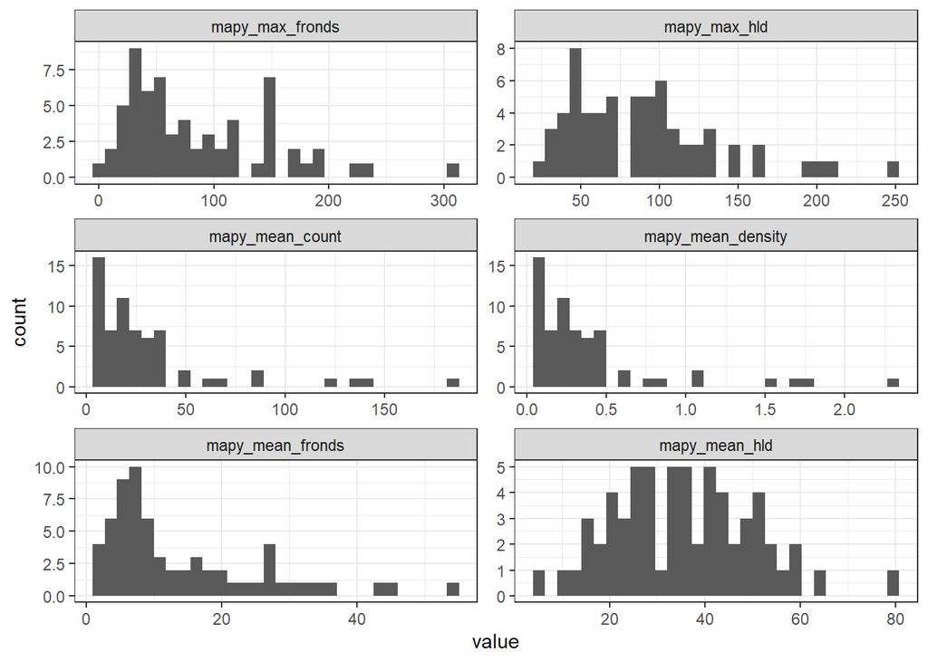

It looks like all but mean holdfast diameter (`mapy_mean_hld`) may not be normal.

```
## $mapy_mean_count
##
##  Shapiro-Wilk normality test
##
## data:  as.numeric(x)
## W = 0.68277, p-value = 1.775e-10
##
##
## $mapy_mean_density
##
##  Shapiro-Wilk normality test
##
## data:  as.numeric(x)
## W = 0.68277, p-value = 1.775e-10
##
##
## $mapy_max_fronds
##
##  Shapiro-Wilk normality test
##
## data:  as.numeric(x)
## W = 0.89582, p-value = 5.587e-05
##
##
## $mapy_mean_fronds
##
##  Shapiro-Wilk normality test
##
## data:  as.numeric(x)
## W = 0.84546, p-value = 1.198e-06
##
##
## $mapy_mean_hld
##
##  Shapiro-Wilk normality test
##
## data:  as.numeric(x)
## W = 0.98297, p-value = 0.5327
##
##
## $mapy_max_hld
##
##  Shapiro-Wilk normality test
##
## data:  as.numeric(x)
## W = 0.91055, p-value = 0.00023
```

Box-Cox suggested transformation:

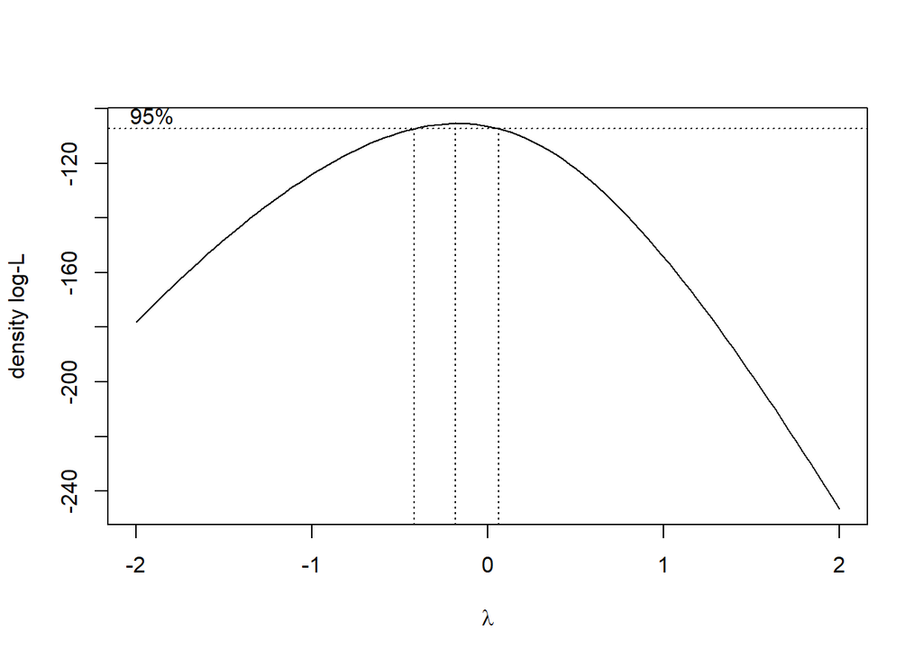

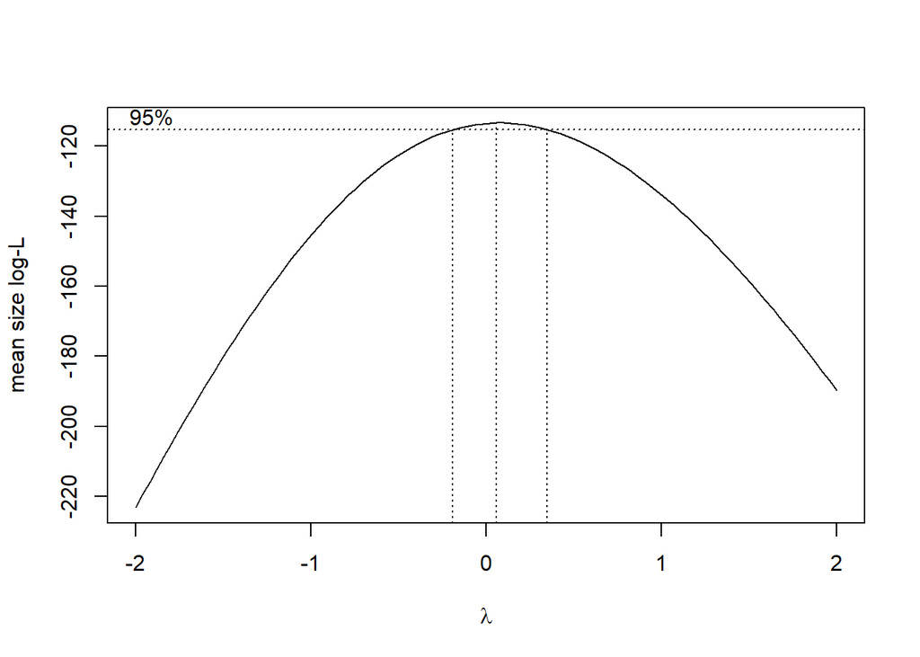

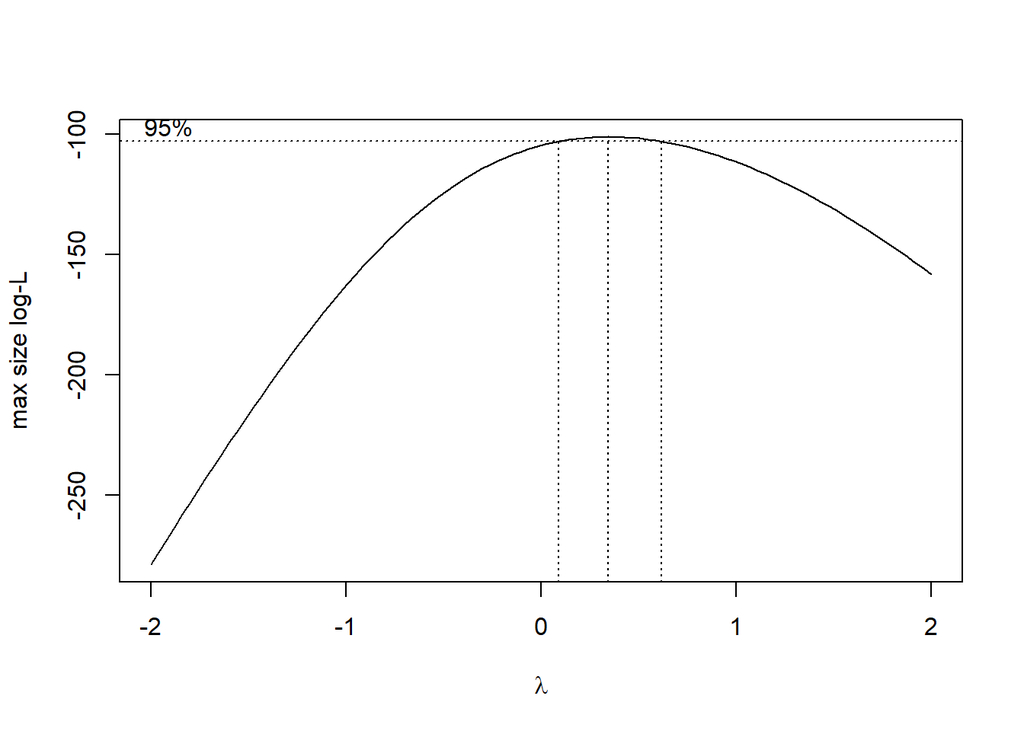

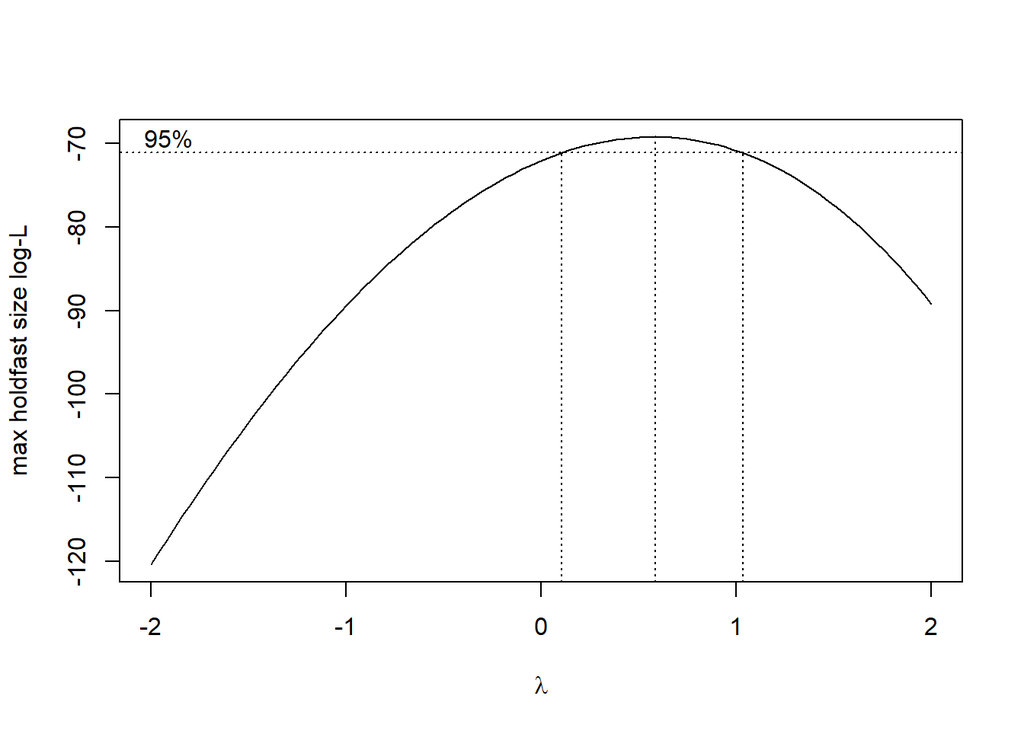

Mean density and mean size should be log, whereas max size and is ~ 0.5 (square root)

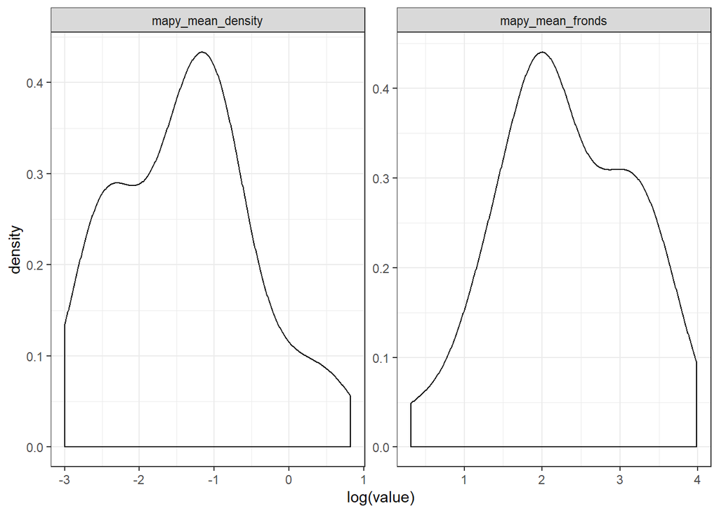

```
## $mapy_mean_density
##
##  Shapiro-Wilk normality test
##
## data:  as.numeric(log(x))
## W = 0.97037, p-value = 0.1264
##
##
## $mapy_mean_fronds
##
##  Shapiro-Wilk normality test
##
## data:  as.numeric(log(x))
## W = 0.9815, p-value = 0.4505
```

Both measures of max size are ~ 0.5 (square root)

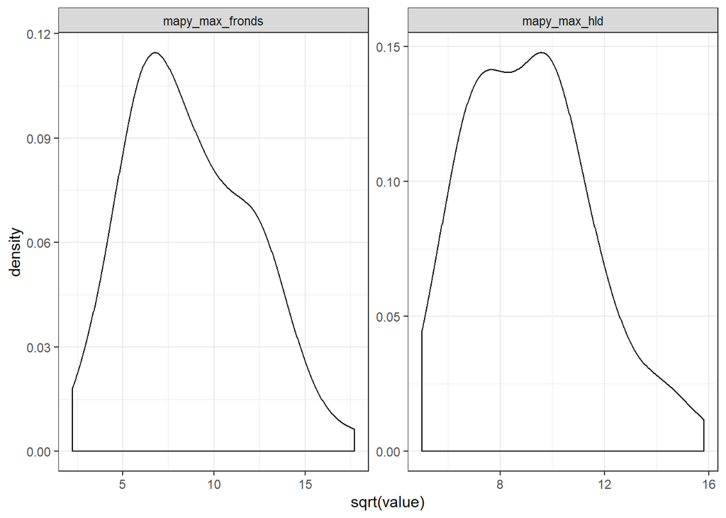

```
## $mapy_max_fronds
##
##  Shapiro-Wilk normality test
##
## data:  as.numeric(sqrt(x))
## W = 0.97481, p-value = 0.2142
##
##
## $mapy_max_hld
##
##  Shapiro-Wilk normality test
##
## data:  as.numeric(sqrt(x))
## W = 0.96947, p-value = 0.1191
```

# Question 2: Biodiversity

## Distributions

### Response

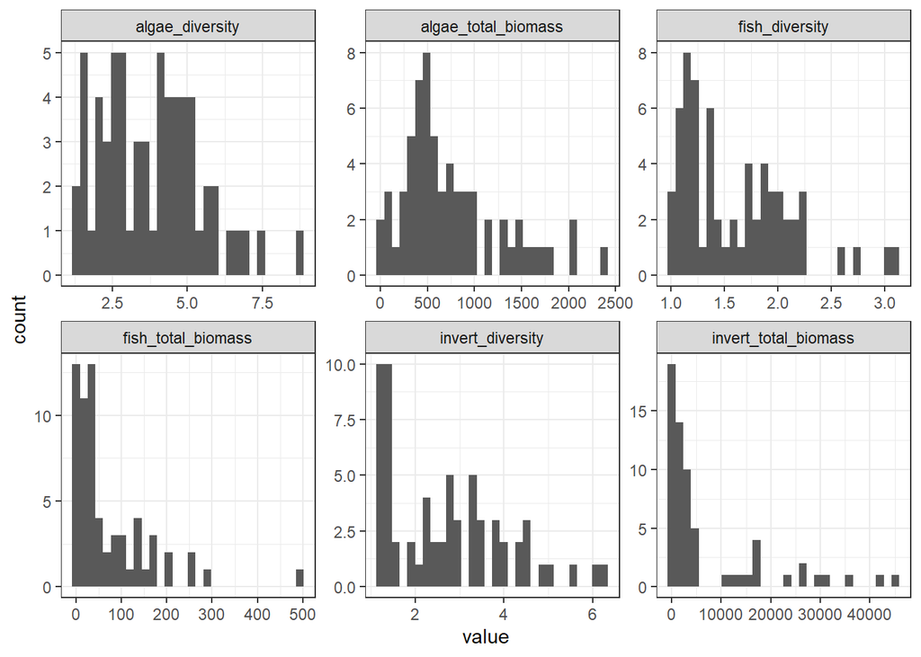

It looks like all of these may not be normal.

```
## $fish_total_biomass
##
##  Shapiro-Wilk normality test
##
## data:  as.numeric(x)
## W = 0.74072, p-value = 2.67e-09
##
##
## $fish_diversity
##
##  Shapiro-Wilk normality test
##
## data:  as.numeric(x)
## W = 0.89902, p-value = 7.351e-05
##
##
## $invert_total_biomass
##
##  Shapiro-Wilk normality test
##
## data:  as.numeric(x)
## W = 0.67487, p-value = 1.259e-10
##
##
## $invert_diversity
##
##  Shapiro-Wilk normality test
##
## data:  as.numeric(x)
## W = 0.91023, p-value = 0.000199
##
##
## $algae_total_biomass
##
##  Shapiro-Wilk normality test
##
## data:  as.numeric(x)
## W = 0.90651, p-value = 0.0001421
##
##
## $algae_diversity
##
##  Shapiro-Wilk normality test
##
## data:  as.numeric(x)
## W = 0.96202, p-value = 0.04645
```

Box-Cox suggested transformation:

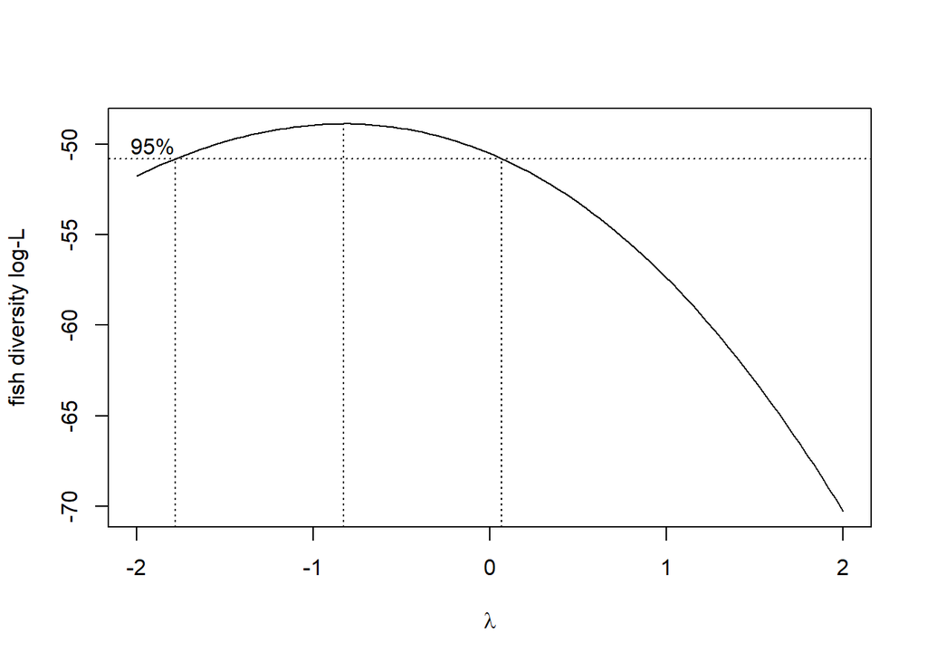

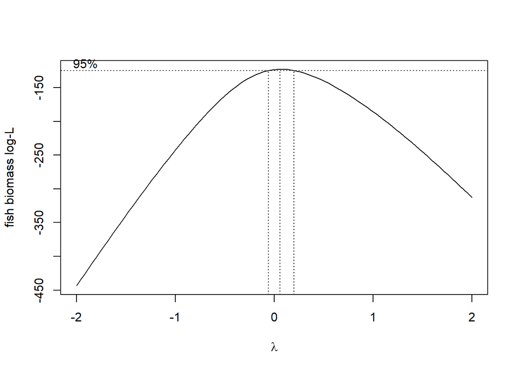

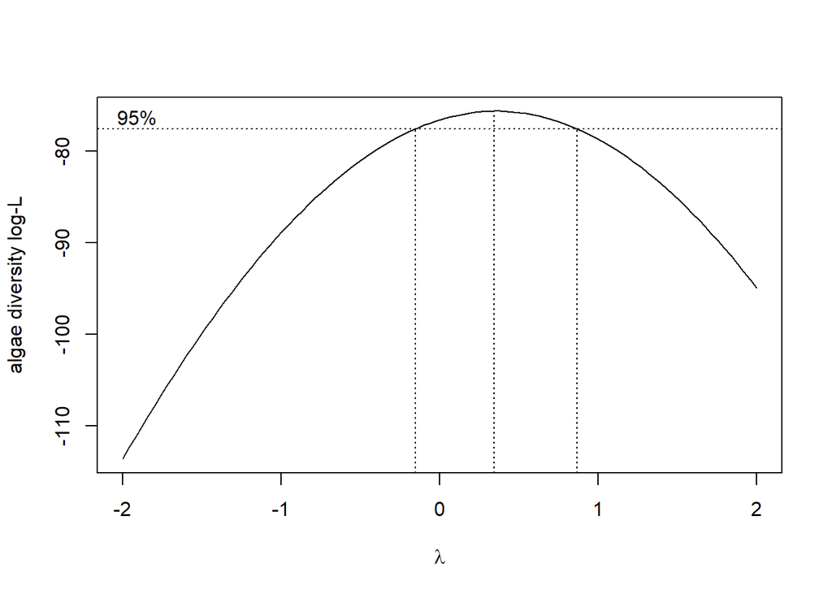

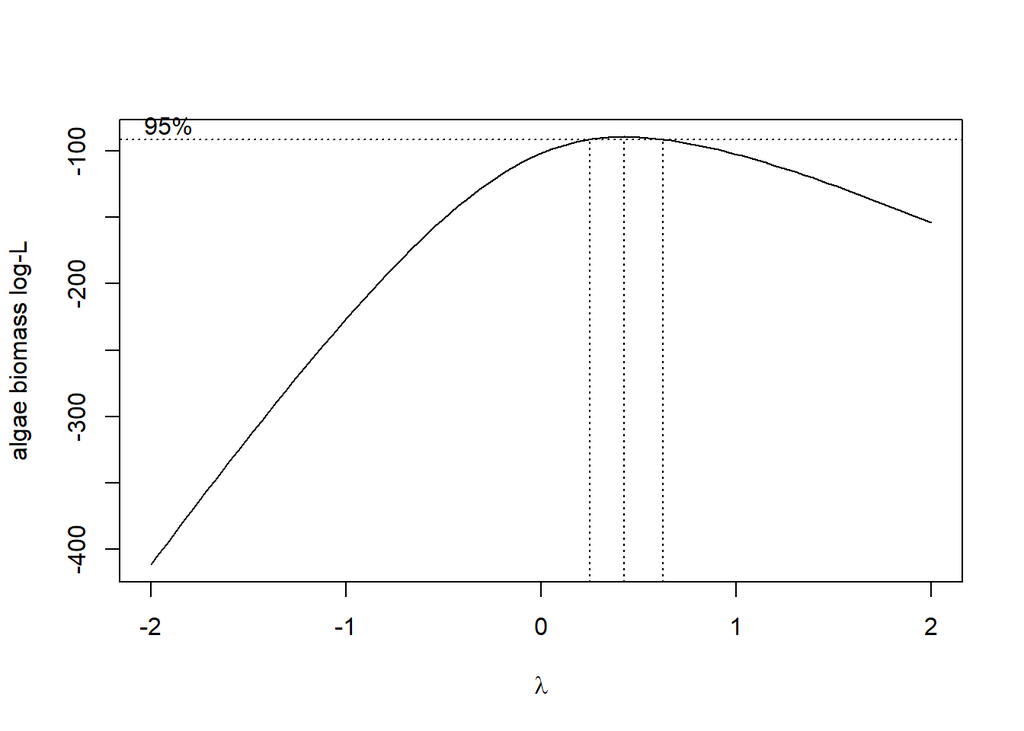

For fish / invert biomass, a log transformation? Invert biomass is still not normal…

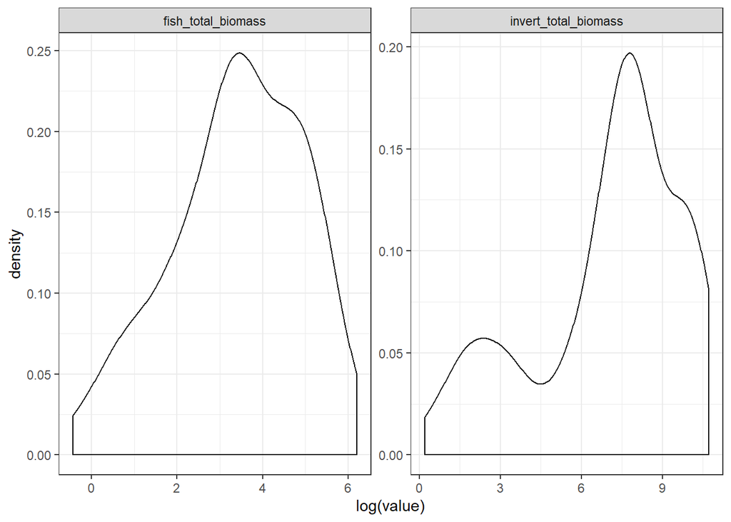

```
## $fish_total_biomass
##
##  Shapiro-Wilk normality test
##
## data:  as.numeric(log(x))
## W = 0.96903, p-value = 0.1077
##
##
## $invert_total_biomass
##
##  Shapiro-Wilk normality test
##
## data:  as.numeric(log(x))
## W = 0.90536, p-value = 0.0001282
```

For fish / invert diversity, $\lambda$ ~ -1. both are still not normal

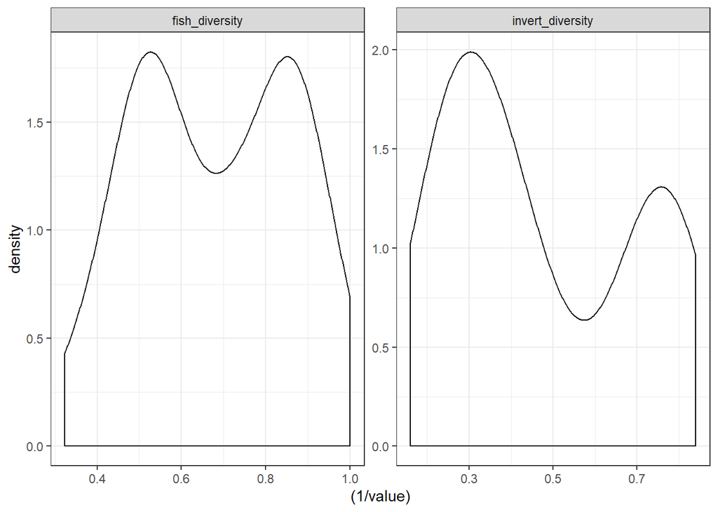

```
## $fish_diversity
##
##  Shapiro-Wilk normality test
##
## data:  as.numeric((1/x))
## W = 0.9471, p-value = 0.008261
##
##
## $invert_diversity
##
##  Shapiro-Wilk normality test
##
## data:  as.numeric((1/x))
## W = 0.88039, p-value = 1.575e-05
```

For algae diversity and biomass, a square root transformation.

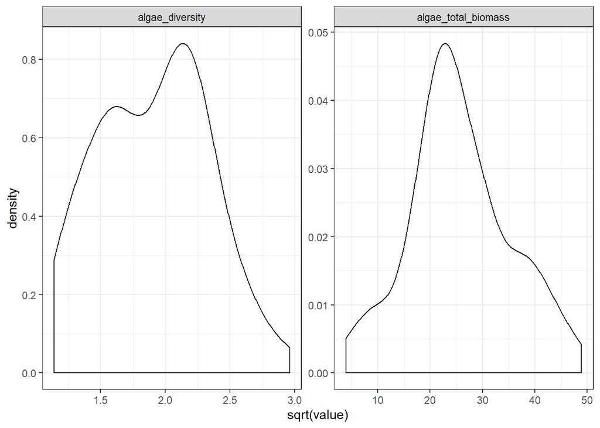

```
## $algae_diversity
##
##  Shapiro-Wilk normality test
##
## data:  as.numeric(sqrt(x))
## W = 0.9782, p-value = 0.3158
##
##
## $algae_total_biomass
##
##  Shapiro-Wilk normality test
##
## data:  as.numeric(sqrt(x))
## W = 0.98291, p-value = 0.5191
```